# clone 1 clone 2 deseq2 analysis

Cindy Liang (celiang@ucsc.edu)

April 03, 2025

# Introduction:

poly(A)-selected RNA from two isogenic clones of human bronchial epithelial cells (HBECs) were sequenced with the Illumina NovaSeq S4 (PE150). Following alignment to a modified version of the GRCh38 reference genome that makes the U2AF1 alignable ([Miller 2022](https://zenodo.org/records/4684553)) with STAR, HTSeq-count was run on the aligned files to produce gene count files.

Please see the project’s [biorxiv](https://www.biorxiv.org/content/10.1101/2024.09.11.612492v1.full#ref-50) and [github repo](https://github.com/cindyeliang/u2af1-kras) for further method details.

Load libraries

```r
library('DESeq2')
library('EnhancedVolcano')
```

Set path location

```r
base_dir <- here::here()

# define the data directory
data_dir <- file.path(base_dir, "data/raw")

# define paths to files

#load clinical metadata -- contains age at dx in years
htseqcount_dir <- file.path(data_dir, "c1c2htseqcount/")
```

Load files

```r
u2af1krasFiles<-grep('clone', list.files(htseqcount_dir),value=TRUE)
u2af1krasFiles
```

```
 [1] "batch2clone1_1_MKV.txt"         "batch2clone1_1_MLA.txt"         "batch2clone1_1_WTK.txt"         "batch2clone1_1_WTL.txt"
 [5] "batch2clone1_2_MKV.txt"         "batch2clone1_2_MLA.txt"         "batch2clone1_2_WTK.txt"         "batch2clone1_2_WTL.txt"
 [9] "batch2clone1_3_MKV.txt"         "batch2clone1_3_MLA.txt"         "batch2clone1_3_WTK.txt"         "batch2clone1_3_WTL.txt"
[13] "clone1U2AF1S34F_KRASG12V_1.tsv" "clone1U2AF1S34F_KRASG12V_2.tsv" "clone1U2AF1S34F_KRASG12V_3.tsv" "clone1U2AF1S34F_LACZ_1.tsv"
[17] "clone1U2AF1S34F_LACZ_2.tsv"     "clone1U2AF1S34F_LACZ_3.tsv"     "clone1U2AF1WT_KRASG12V_1.tsv"   "clone1U2AF1WT_KRASG12V_2.tsv"
[21] "clone1U2AF1WT_KRASG12V_3.tsv"   "clone1U2AF1WT_LACZ_1.tsv"       "clone1U2AF1WT_LACZ_2.tsv"       "clone1U2AF1WT_LACZ_3.tsv"
[25] "clone2U2AF1S34FKRASG12V_1.tsv"  "clone2U2AF1S34FKRASG12V_2.tsv"  "clone2U2AF1S34FKRASG12V_3.tsv"  "clone2U2AF1S34FLACZ_1.tsv"
[29] "clone2U2AF1S34FLACZ_2.tsv"      "clone2U2AF1S34FLACZ_3.tsv"      "clone2U2AF1WTKRASG12V_1.tsv"    "clone2U2AF1WTKRASG12V_2.tsv"
[33] "clone2U2AF1WTKRASG12V_3.tsv"    "clone2U2AF1WTLACZ_1.tsv"        "clone2U2AF1WTLACZ_2.tsv"        "clone2U2AF1WTLACZ_3.tsv"
```

Create sample table

```r
u2af1krasBatch<-c("clone1", "clone1", "clone1", "clone1", "clone1", "clone1", "clone1", "clone1", "clone1", "clone1", "clone1", "clone1", "clone1", "clone1", "clone1", "clone1", "clone1", "clone1", "clone1", "clone1", "clone1", "clone1", "clone1", "clone1", "clone2", "clone2", "clone2", "clone2", "clone2", "clone2", "clone2", "clone2", "clone2", "clone2", "clone2", "clone2")

u2af1krasSample<-c("U2AF1_S34F_KRAS_G12V_1", "U2AF1_S34F_LACZ_1", 'U2AF1_WT_KRAS_G12V_1', 'U2AF1_WT_LACZ_1', "U2AF1_S34F_KRAS_G12V_2", "U2AF1_S34F_LACZ_2", 'U2AF1_WT_KRAS_G12V_2', 'U2AF1_WT_LACZ_2', "U2AF1_S34F_KRAS_G12V_3", "U2AF1_S34F_LACZ_3", 'U2AF1_WT_KRAS_G12V_3', 'U2AF1_WT_LACZ_3', "U2AF1_S34F_KRAS_G12V_1", "U2AF1_S34F_KRAS_G12V_2", "U2AF1_S34F_KRAS_G12V_3", "U2AF1_S34F_LACZ_1", "U2AF1_S34F_LACZ_2", "U2AF1_S34F_LACZ_3", 'U2AF1_WT_KRAS_G12V_1', 'U2AF1_WT_KRAS_G12V_2', 'U2AF1_WT_KRAS_G12V_3', 'U2AF1_WT_LACZ_1', 'U2AF1_WT_LACZ_2', 'U2AF1_WT_LACZ_3', "U2AF1_S34F_KRAS_G12V_4", "U2AF1_S34F_KRAS_G12V_5", "U2AF1_S34F_KRAS_G12V_6", "U2AF1_S34F_LACZ_4", "U2AF1_S34F_LACZ_5", "U2AF1_S34F_LACZ_6", 'U2AF1_WT_KRAS_G12V_4', 'U2AF1_WT_KRAS_G12V_5', 'U2AF1_WT_KRAS_G12V_6', 'U2AF1_WT_LACZ_4', 'U2AF1_WT_LACZ_5', 'U2AF1_WT_LACZ_6')

u2af1krasRun <-c("U2AF1_S34F_KRAS_G12V_a", "U2AF1_S34F_LACZ_a", 'U2AF1_WT_KRAS_G12V_a', 'U2AF1_WT_LACZ_a', "U2AF1_S34F_KRAS_G12V_b", "U2AF1_S34F_LACZ_b", 'U2AF1_WT_KRAS_G12V_b', 'U2AF1_WT_LACZ_b', "U2AF1_S34F_KRAS_G12V_c", "U2AF1_S34F_LACZ_c", 'U2AF1_WT_KRAS_G12V_c', 'U2AF1_WT_LACZ_c', "U2AF1_S34F_KRAS_G12V_d", "U2AF1_S34F_KRAS_G12V_e", "U2AF1_S34F_KRAS_G12V_f", "U2AF1_S34F_LACZ_d", "U2AF1_S34F_LACZ_e", "U2AF1_S34F_LACZ_f", 'U2AF1_WT_KRAS_G12V_d', 'U2AF1_WT_KRAS_G12V_e', 'U2AF1_WT_KRAS_G12V_f', 'U2AF1_WT_LACZ_d', 'U2AF1_WT_LACZ_e', 'U2AF1_WT_LACZ_f', "U2AF1_S34F_KRAS_G12V_g", "U2AF1_S34F_KRAS_G12V_h", "U2AF1_S34F_KRAS_G12V_i", "U2AF1_S34F_LACZ_g", "U2AF1_S34F_LACZ_h", "U2AF1_S34F_LACZ_i", 'U2AF1_WT_KRAS_G12V_g', 'U2AF1_WT_KRAS_G12V_h', 'U2AF1_WT_KRAS_G12V_i', 'U2AF1_WT_LACZ_g', 'U2AF1_WT_LACZ_h', 'U2AF1_WT_LACZ_i')

u2af1kras_samplecondition <- c('U2AF1_S34F_KRAS_G12V', 'U2AF1_S34F_LACZ', 'U2AF1_WT_KRAS_G12V', 'U2AF1_WT_LACZ', 'U2AF1_S34F_KRAS_G12V', 'U2AF1_S34F_LACZ', 'U2AF1_WT_KRAS_G12V', 'U2AF1_WT_LACZ', 'U2AF1_S34F_KRAS_G12V', 'U2AF1_S34F_LACZ', 'U2AF1_WT_KRAS_G12V', 'U2AF1_WT_LACZ', 'U2AF1_S34F_KRAS_G12V', 'U2AF1_S34F_KRAS_G12V', 'U2AF1_S34F_KRAS_G12V', 'U2AF1_S34F_LACZ', 'U2AF1_S34F_LACZ', 'U2AF1_S34F_LACZ', 'U2AF1_WT_KRAS_G12V', 'U2AF1_WT_KRAS_G12V', 'U2AF1_WT_KRAS_G12V', 'U2AF1_WT_LACZ', 'U2AF1_WT_LACZ', 'U2AF1_WT_LACZ', 'U2AF1_S34F_KRAS_G12V', 'U2AF1_S34F_KRAS_G12V', 'U2AF1_S34F_KRAS_G12V', 'U2AF1_S34F_LACZ', 'U2AF1_S34F_LACZ', 'U2AF1_S34F_LACZ', 'U2AF1_WT_KRAS_G12V', 'U2AF1_WT_KRAS_G12V', 'U2AF1_WT_KRAS_G12V', 'U2AF1_WT_LACZ', 'U2AF1_WT_LACZ', 'U2AF1_WT_LACZ')

u2af1krassampleTable<-data.frame(sampleName=u2af1krasFiles, fileName=u2af1krasFiles, condition=u2af1kras_samplecondition, batch=u2af1krasBatch, sample=u2af1krasSample, run=u2af1krasRun)

u2af1krassampleTable
```

| sampleName | fileName | condition | batch | sample | run |
| --- | --- | --- | --- | --- | --- |
| batch2clone1_1_MKV.txt | batch2clone1_1_MKV.txt | U2AF1_S34F_KRAS_G12V | clone1 | U2AF1_S34F_KRAS_G12V_1 | U2AF1_S34F_KRAS_G12V_a |
| batch2clone1_1_MLA.txt | batch2clone1_1_MLA.txt | U2AF1_S34F_LACZ | clone1 | U2AF1_S34F_LACZ_1 | U2AF1_S34F_LACZ_a |
| batch2clone1_1_WTK.txt | batch2clone1_1_WTK.txt | U2AF1_WT_KRAS_G12V | clone1 | U2AF1_WT_KRAS_G12V_1 | U2AF1_WT_KRAS_G12V_a |
| batch2clone1_1_WTL.txt | batch2clone1_1_WTL.txt | U2AF1_WT_LACZ | clone1 | U2AF1_WT_LACZ_1 | U2AF1_WT_LACZ_a |
| batch2clone1_2_MKV.txt | batch2clone1_2_MKV.txt | U2AF1_S34F_KRAS_G12V | clone1 | U2AF1_S34F_KRAS_G12V_2 | U2AF1_S34F_KRAS_G12V_b |
| batch2clone1_2_MLA.txt | batch2clone1_2_MLA.txt | U2AF1_S34F_LACZ | clone1 | U2AF1_S34F_LACZ_2 | U2AF1_S34F_LACZ_b |
| batch2clone1_2_WTK.txt | batch2clone1_2_WTK.txt | U2AF1_WT_KRAS_G12V | clone1 | U2AF1_WT_KRAS_G12V_2 | U2AF1_WT_KRAS_G12V_b |
| batch2clone1_2_WTL.txt | batch2clone1_2_WTL.txt | U2AF1_WT_LACZ | clone1 | U2AF1_WT_LACZ_2 | U2AF1_WT_LACZ_b |
| batch2clone1_3_MKV.txt | batch2clone1_3_MKV.txt | U2AF1_S34F_KRAS_G12V | clone1 | U2AF1_S34F_KRAS_G12V_3 | U2AF1_S34F_KRAS_G12V_c |
| batch2clone1_3_MLA.txt | batch2clone1_3_MLA.txt | U2AF1_S34F_LACZ | clone1 | U2AF1_S34F_LACZ_3 | U2AF1_S34F_LACZ_c |

[output cut: 26 more lines]

Construct deseq dataset

```r
u2af1kras_ddsHTSeq<-DESeqDataSetFromHTSeqCount(sampleTable=u2af1krassampleTable, directory=htseqcount_dir, design= ~batch + condition)
# collapse technical replicates of clone 1

u2af1krasddsColl <-collapseReplicates(u2af1kras_ddsHTSeq, u2af1kras_ddsHTSeq$sample, u2af1kras_ddsHTSeq$run)

# set wt lacz as control
u2af1krasddsColl$condition <- relevel(u2af1krasddsColl$condition, ref = 'U2AF1_WT_LACZ')

colData(u2af1krasddsColl)
```

```
DataFrame with 24 rows and 5 columns
                                  condition    batch                 sample                    run          runsCollapsed
                                   <factor> <factor>            <character>            <character>            <character>
U2AF1_S34F_KRAS_G12V_1 U2AF1_S34F_KRAS_G12V   clone1 U2AF1_S34F_KRAS_G12V_1 U2AF1_S34F_KRAS_G12V_a U2AF1_S34F_KRAS_G12V..
U2AF1_S34F_KRAS_G12V_2 U2AF1_S34F_KRAS_G12V   clone1 U2AF1_S34F_KRAS_G12V_2 U2AF1_S34F_KRAS_G12V_b U2AF1_S34F_KRAS_G12V..
U2AF1_S34F_KRAS_G12V_3 U2AF1_S34F_KRAS_G12V   clone1 U2AF1_S34F_KRAS_G12V_3 U2AF1_S34F_KRAS_G12V_c U2AF1_S34F_KRAS_G12V..
U2AF1_S34F_KRAS_G12V_4 U2AF1_S34F_KRAS_G12V   clone2 U2AF1_S34F_KRAS_G12V_4 U2AF1_S34F_KRAS_G12V_g U2AF1_S34F_KRAS_G12V_g
U2AF1_S34F_KRAS_G12V_5 U2AF1_S34F_KRAS_G12V   clone2 U2AF1_S34F_KRAS_G12V_5 U2AF1_S34F_KRAS_G12V_h U2AF1_S34F_KRAS_G12V_h
...                                     ...      ...                    ...                    ...                    ...
U2AF1_WT_LACZ_2               U2AF1_WT_LACZ   clone1        U2AF1_WT_LACZ_2        U2AF1_WT_LACZ_b U2AF1_WT_LACZ_b,U2AF..
U2AF1_WT_LACZ_3               U2AF1_WT_LACZ   clone1        U2AF1_WT_LACZ_3        U2AF1_WT_LACZ_c U2AF1_WT_LACZ_c,U2AF..
U2AF1_WT_LACZ_4               U2AF1_WT_LACZ   clone2        U2AF1_WT_LACZ_4        U2AF1_WT_LACZ_g        U2AF1_WT_LACZ_g
U2AF1_WT_LACZ_5               U2AF1_WT_LACZ   clone2        U2AF1_WT_LACZ_5        U2AF1_WT_LACZ_h        U2AF1_WT_LACZ_h
U2AF1_WT_LACZ_6               U2AF1_WT_LACZ   clone2        U2AF1_WT_LACZ_6        U2AF1_WT_LACZ_i        U2AF1_WT_LACZ_i
```

Perform DE analysis on collapsed dataset

```r
u2af1kras_dds<-DESeq(u2af1krasddsColl)
u2af1kras_dds
```

```
class: DESeqDataSet
dim: 60642 24
metadata(1): version
assays(4): counts mu H cooks
rownames(60642): A1BG A1BG-AS1 ... hsa-mir-1253 hsa-mir-423
rowData names(34): baseMean baseVar ... deviance maxCooks
colnames(24): U2AF1_S34F_KRAS_G12V_1 U2AF1_S34F_KRAS_G12V_2 ... U2AF1_WT_LACZ_5 U2AF1_WT_LACZ_6
colData names(6): condition batch ... runsCollapsed sizeFactor
```

Plot individual gene normalized counts

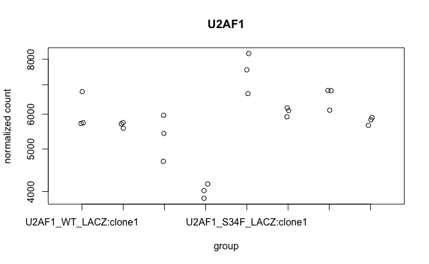

```r
plotCounts(u2af1kras_dds, gene='U2AF1', intgroup=c('condition', 'batch'))
```

KRAS normalized counts

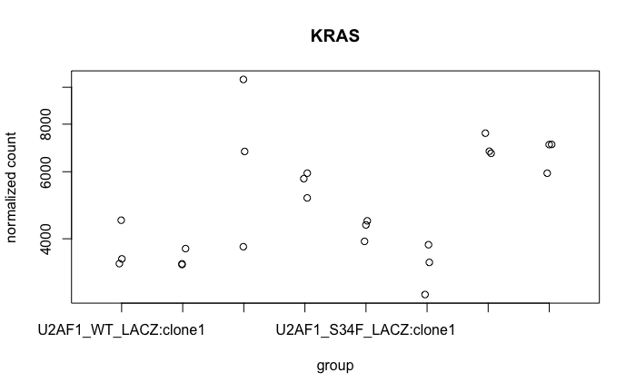

```r
plotCounts(u2af1kras_dds, gene='KRAS', intgroup=c('condition', 'batch'))
```

H2AFY

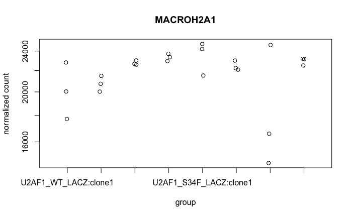

```r
plotCounts(u2af1kras_dds, gene='MACROH2A1', intgroup=c('condition', 'batch'))
```

Perform likelihood ratio test

```r
#perform likelihood ratio test
u2af1krasLRTbatch_dds <- DESeq(u2af1kras_dds, test="LRT", reduced=~batch)
```

```
found already estimated dispersions, replacing these
```

Generate contrasts

```r
c1collapsed_u2af1s34f_lacz_vs_wtlacz_res <- DESeq2::results(u2af1krasLRTbatch_dds, contrast=c("condition", "U2AF1_S34F_LACZ", "U2AF1_WT_LACZ"))

c1collapsed_u2af1wtkv12_vs_wtlacz_res <- DESeq2::results(u2af1krasLRTbatch_dds, contrast=c("condition", "U2AF1_WT_KRAS_G12V", "U2AF1_WT_LACZ"))

c1collapsed_u2af1s34f_kv12_vs_wtlacz_res <- DESeq2::results(u2af1krasLRTbatch_dds, contrast=c("condition", "U2AF1_S34F_KRAS_G12V", "U2AF1_WT_LACZ"))
```

Plot volcano plots

s34f lacz

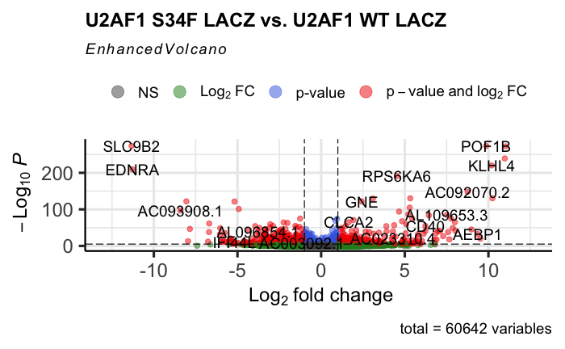

```r
library('EnhancedVolcano')
EnhancedVolcano(c1collapsed_u2af1s34f_lacz_vs_wtlacz_res,
                lab=rownames(c1collapsed_u2af1s34f_lacz_vs_wtlacz_res),
                x='log2FoldChange', y='pvalue', title="U2AF1 S34F LACZ vs. U2AF1 WT LACZ")
```

wt kv12

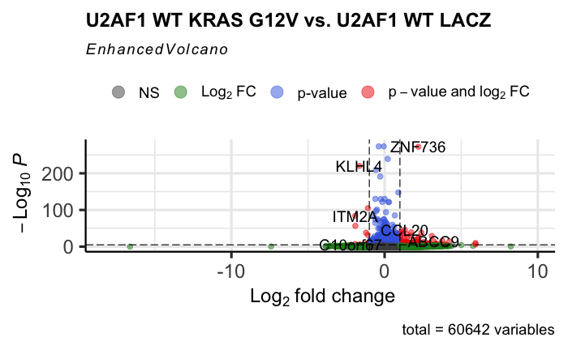

```r
EnhancedVolcano(c1collapsed_u2af1wtkv12_vs_wtlacz_res,
                lab=rownames(c1collapsed_u2af1wtkv12_vs_wtlacz_res),
                x='log2FoldChange', y='pvalue', title="U2AF1 WT KRAS G12V vs. U2AF1 WT LACZ")
```

s34f kv12

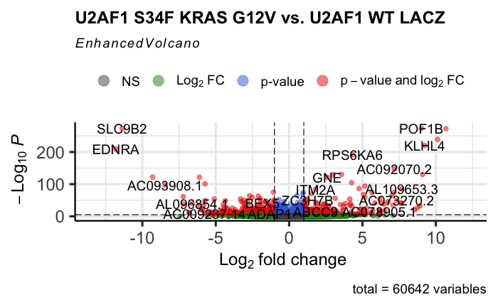

```r
EnhancedVolcano(c1collapsed_u2af1s34f_kv12_vs_wtlacz_res, lab=rownames(c1collapsed_u2af1s34f_kv12_vs_wtlacz_res), x='log2FoldChange', y='pvalue', title="U2AF1 S34F KRAS G12V vs. U2AF1 WT LACZ")
```

Export contrasts

```r
collapsedfiltered_u2af1s34f_lacz_vs_wtlacz_res <- c1collapsed_u2af1s34f_lacz_vs_wtlacz_res[!is.na(c1collapsed_u2af1s34f_lacz_vs_wtlacz_res$padj) & c1collapsed_u2af1s34f_lacz_vs_wtlacz_res$padj<0.05,]

collapsedfiltered_u2af1wtkv12_vs_wtlacz_res <- c1collapsed_u2af1wtkv12_vs_wtlacz_res[!is.na(c1collapsed_u2af1wtkv12_vs_wtlacz_res$padj) & c1collapsed_u2af1wtkv12_vs_wtlacz_res$padj<0.05,]

collapsedfilteredu2af1s34f_kv12_vs_wtlacz_res <- c1collapsed_u2af1s34f_kv12_vs_wtlacz_res[!is.na(c1collapsed_u2af1s34f_kv12_vs_wtlacz_res$padj) & c1collapsed_u2af1s34f_kv12_vs_wtlacz_res$padj<0.05,]

write.csv(as.data.frame(collapsedfiltered_u2af1s34f_lacz_vs_wtlacz_res), file='~/Desktop/20241127filtered_u2af1s34f_lacz_vs_wtlacz_res')

write.csv(as.data.frame(collapsedfiltered_u2af1wtkv12_vs_wtlacz_res), file='~/Desktop/20241127filtered_u2af1wtkv12_lacz_vs_wtlacz_res')

write.csv(as.data.frame(collapsedfilteredu2af1s34f_kv12_vs_wtlacz_res), file='~/Desktop/20241127filtered_u2af1s34f_kv12_vs_wtlacz_res')
```